# Case Study 2

Healthcare Representative - 10.5% Human Resources - 22.2% Laboratory Technician - 19.6% Manager - 7.84% Manufacturing Director - 2.29% Research Director - 1.96% Research Scientist - 18.6% Sales Executive - 16.5% Sales Representative - 45.28%

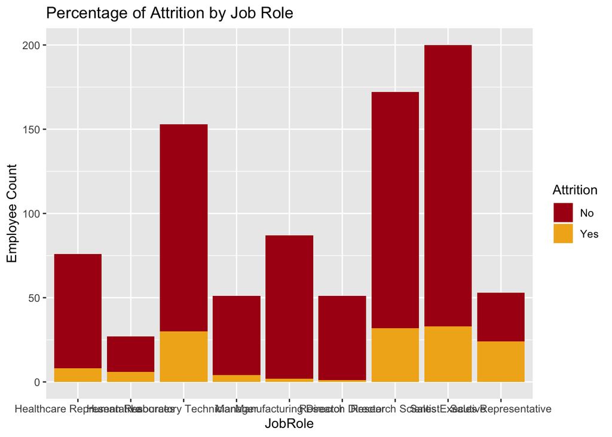

```r
CaseStudy2 %>%
  ggplot(aes(x= JobRole, fill=Attrition)) +
  geom_bar(stat = "count") + scale_fill_manual(values = colors5) +
  ggtitle("Percentage of Attrition by Job Role") + ylab("Employee Count")
```

```r
(sum(CaseStudy2$JobRole == "Healthcare Representative" & CaseStudy2$Attrition == "Yes")/sum(CaseStudy2$JobRole == "Healthcare Representative"))* 100
```

```
## [1] 10.52632
```

```r
(sum(CaseStudy2$JobRole == "Human Resources" & CaseStudy2$Attrition == "Yes")/sum(CaseStudy2$JobRole == "Human Resources"))* 100
```

```
## [1] 22.22222
```

```r
(sum(CaseStudy2$JobRole == "Manager" & CaseStudy2$Attrition == "Yes")/sum(CaseStudy2$JobRole == "Manager"))* 100
```

```
## [1] 7.843137
```

```r
(sum(CaseStudy2$JobRole == "Manufacturing Director" & CaseStudy2$Attrition == "Yes")/sum(CaseStudy2$JobRole == "Manufacturing Director"))* 100
```

```
## [1] 2.298851
```

```r
(sum(CaseStudy2$JobRole == "Research Director" & CaseStudy2$Attrition == "Yes")/sum(CaseStudy2$JobRole == "Research Director"))* 100
```

```
## [1] 1.960784
```

```r
(sum(CaseStudy2$JobRole == "Research Scientist" & CaseStudy2$Attrition == "Yes")/sum(CaseStudy2$JobRole == "Research Scientist"))* 100
```

```
## [1] 18.60465
```

```r
(sum(CaseStudy2$JobRole == "Laboratory Technician" & CaseStudy2$Attrition == "Yes")/sum(CaseStudy2$JobRole == "Laboratory Technician"))* 100
```

```
## [1] 19.60784
```

```r
(sum(CaseStudy2$JobRole == "Sales Executive" & CaseStudy2$Attrition == "Yes")/sum(CaseStudy2$JobRole == "Sales Executive"))* 100
```

```
## [1] 16.5
```

```r
(sum(CaseStudy2$JobRole == "Sales Representative" & CaseStudy2$Attrition == "Yes")/sum(CaseStudy2$JobRole == "Sales Representative"))* 100
```

```
## [1] 45.28302
```

```r
(sum(CaseStudy2$PerformanceRating == "4" & CaseStudy2$Attrition == "Yes")/sum(CaseStudy2$PerformanceRating == "4"))* 100
```

```
## [1] 17.42424
```

#Chi-Square Test - Contingency Table for Department & Job Role

[output not shown]

[output not shown]

[output not shown]

[output not shown]

```r
tbl = table(CaseStudy2$Department, CaseStudy2$Attrition)
tbl
```

```
##
##                           No Yes
##   Human Resources         29   6
##   Research & Development 487  75
##   Sales                  214  59
```

```r
chisq.test((tbl))
```

```
##
##  Pearson's Chi-squared test
##
## data:  (tbl)
## X-squared = 9.329, df = 2, p-value = 0.009424
```

```r
JobRoletbl = table(CaseStudy2$JobRole, CaseStudy2$Attrition)
JobRoletbl
```

```
##
##                              No Yes
##   Healthcare Representative  68   8
##   Human Resources            21   6
##   Laboratory Technician     123  30
##   Manager                    47   4
##   Manufacturing Director     85   2
##   Research Director          50   1
##   Research Scientist        140  32
##   Sales Executive           167  33
##   Sales Representative       29  24
```

```r
chisq.test(JobRoletbl)
```

```
##
##  Pearson's Chi-squared test
##
## data:  JobRoletbl
## X-squared = 60.543, df = 8, p-value = 3.647e-10
```

#Age I converted the numeric age to factor. There is evidence(Pearson’s chi-squared X-squared = 27.929, df = 4, p-value = 1.289e-05) that younger or early career employees are not sticking around with 30% of employees age 18-24 and 22% of employees age 25-33 leaving as compared to 10% of employees age 34-44 and 12% of employees age 45-55 leaving.

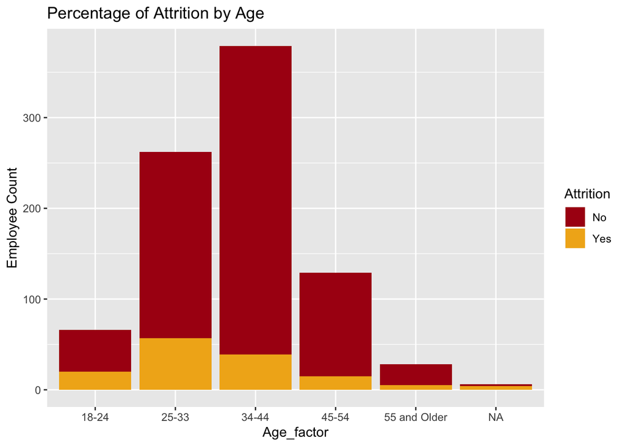

```r
CaseStudy2$Age_factor = cut(CaseStudy2$Age, breaks = c(18,25,33,45,55,100), labels = c("18-24","25-33","34-44","45-54","55 and Older"))

CaseStudy2 %>%
  ggplot(aes(x= Age_factor, fill=Attrition)) +
  geom_bar(stat = "count") + scale_fill_manual(values = colors5) +
  ggtitle("Percentage of Attrition by Age") + ylab("Employee Count")
```

```r
(sum(CaseStudy2$Age_factor == "1" & CaseStudy2$Attrition == "Yes")/sum(CaseStudy2$Age_factor == "1"))*100
```

```
## [1] NA
```

```r
max(CaseStudy2$Age)
```

```
## [1] 60
```

```r
AFtbl = table(CaseStudy2$Age_factor, CaseStudy2$Attrition)
AFtbl
```

```
##
##                 No Yes
##   18-24         46  20
##   25-33        205  57
##   34-44        340  39
##   45-54        114  15
##   55 and Older  23   5
```

```r
chisq.test(AFtbl)
```

```
##
##  Pearson's Chi-squared test
##
## data:  AFtbl
## X-squared = 27.929, df = 4, p-value = 1.289e-05
```

#Education Not significant

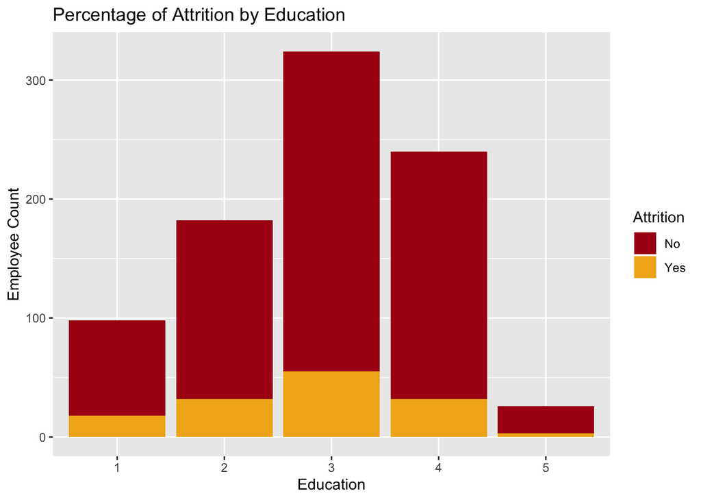

```r
CaseStudy2 %>%
  ggplot(aes(x= Education, fill=Attrition)) +
  geom_bar(stat = "count") + scale_fill_manual(values = colors5) +
  ggtitle("Percentage of Attrition by Education") + ylab("Employee Count")
```

```r
Educationtbl = table(CaseStudy2$Education, CaseStudy2$Attrition)
Educationtbl
```

```
##
##      No Yes
##   1  80  18
##   2 150  32
##   3 269  55
##   4 208  32
##   5  23   3
```

```r
chisq.test(Educationtbl)
```

```
##
##  Pearson's Chi-squared test
##
## data:  Educationtbl
## X-squared = 2.6143, df = 4, p-value = 0.6243
```

#Business Travel Significant p=.0499

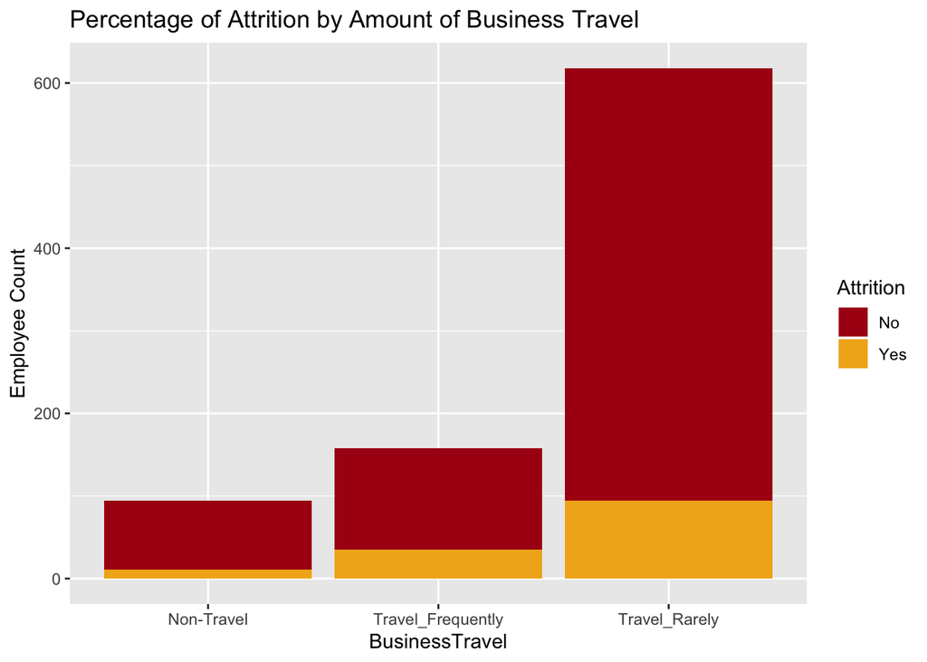

```r
CaseStudy2 %>%
  ggplot(aes(x= BusinessTravel, fill=Attrition)) +
  geom_bar(stat = "count") + scale_fill_manual(values = colors5) +
  ggtitle("Percentage of Attrition by Amount of Business Travel") + ylab("Employee Count")
```

```r
Traveltbl = table(CaseStudy2$BusinessTravel, CaseStudy2$Attrition)
Educationtbl
```

```
##
##      No Yes
##   1  80  18
##   2 150  32
##   3 269  55
##   4 208  32
##   5  23   3
```

```r
chisq.test(Traveltbl)
```

```
##
##  Pearson's Chi-squared test
##
## data:  Traveltbl
## X-squared = 5.9945, df = 2, p-value = 0.04993
```

#Env Satisfaction Travel - Significant p=0.01

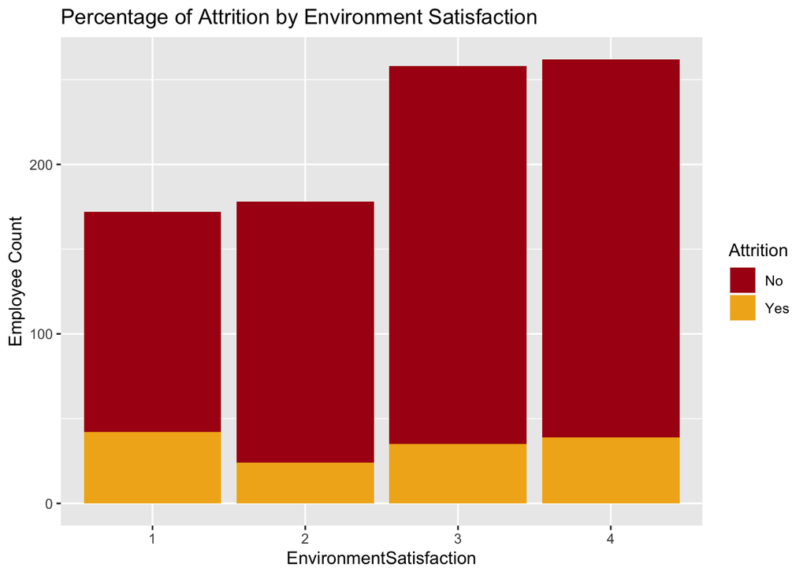

```r
CaseStudy2 %>%
  ggplot(aes(x= EnvironmentSatisfaction, fill=Attrition)) +
  geom_bar(stat = "count") + scale_fill_manual(values = colors5) +
  ggtitle("Percentage of Attrition by Environment Satisfaction") + ylab("Employee Count")
```

```r
Envtbl = table(CaseStudy2$EnvironmentSatisfaction, CaseStudy2$Attrition)
Envtbl
```

```
##
##      No Yes
##   1 130  42
##   2 154  24
##   3 223  35
##   4 223  39
```

```r
chisq.test(Envtbl)
```

```
##
##  Pearson's Chi-squared test
##
## data:  Envtbl
## X-squared = 11.231, df = 3, p-value = 0.01054
```

#JobInvolvement - Significant p-value = 5.211e-09

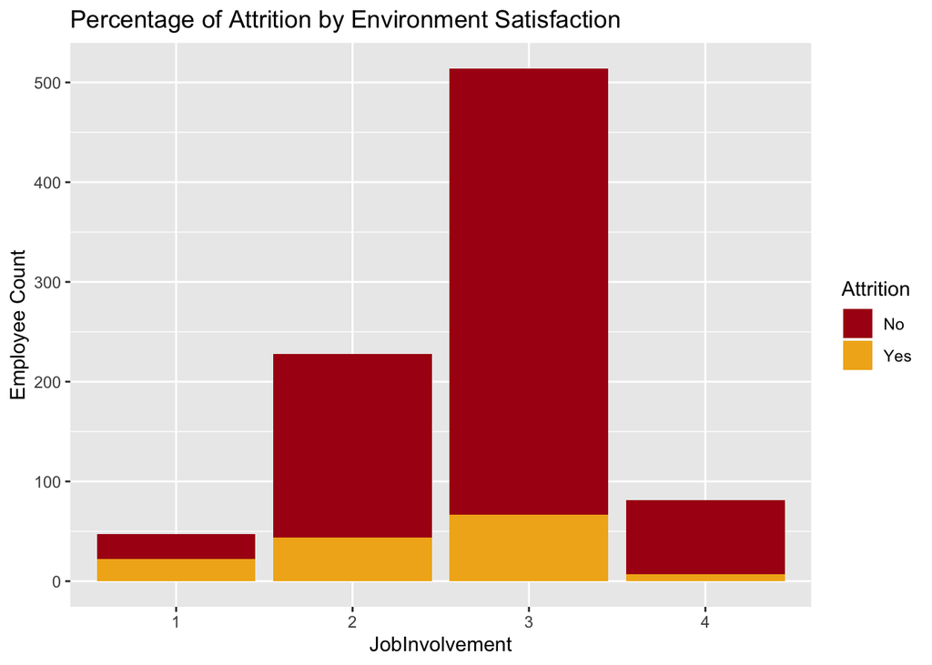

```r
CaseStudy2 %>%
  ggplot(aes(x= JobInvolvement, fill=Attrition)) +
  geom_bar(stat = "count") + scale_fill_manual(values = colors5) +
  ggtitle("Percentage of Attrition by Environment Satisfaction") + ylab("Employee Count")
```

```r
JItbl = table(CaseStudy2$JobInvolvement, CaseStudy2$Attrition)
JItbl
```

```
##
##      No Yes
##   1  25  22
##   2 184  44
##   3 447  67
##   4  74   7
```

```r
chisq.test(JItbl)
```

```
##
##  Pearson's Chi-squared test
##
## data:  JItbl
## X-squared = 41.465, df = 3, p-value = 5.211e-09
```

#Stock Level Options Significant p-value = 3.724e-12

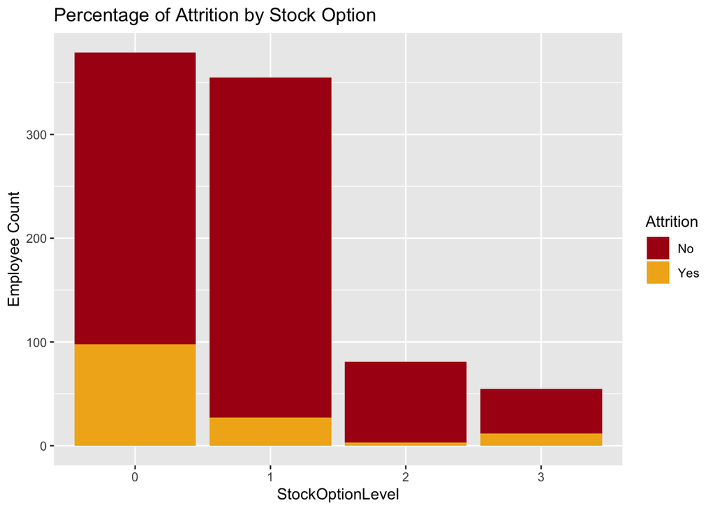

```r
CaseStudy2 %>%
  ggplot(aes(x= StockOptionLevel, fill=Attrition)) +
  geom_bar(stat = "count") + scale_fill_manual(values = colors5) +
  ggtitle("Percentage of Attrition by Stock Option") + ylab("Employee Count")
```

```r
SOtbl = table(CaseStudy2$StockOptionLevel, CaseStudy2$Attrition)
chisq.test(SOtbl)
```

```
##
##  Pearson's Chi-squared test
##
## data:  SOtbl
## X-squared = 56.245, df = 3, p-value = 3.724e-12
```

#Overtime p-value = 2.333e-15

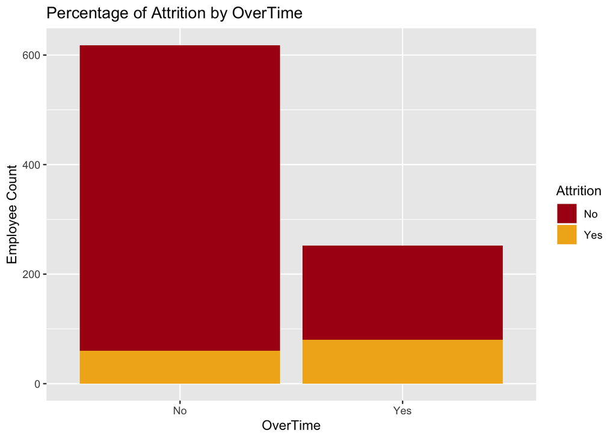

```r
CaseStudy2 %>%
  ggplot(aes(x= OverTime, fill=Attrition)) +
  geom_bar(stat = "count") + scale_fill_manual(values = colors5) +
  ggtitle("Percentage of Attrition by OverTime") + ylab("Employee Count")
```

```r
ottbl = table(CaseStudy2$OverTime, CaseStudy2$Attrition)
chisq.test(ottbl)
```

```
##
##  Pearson's Chi-squared test with Yates' continuity correction
##
## data:  ottbl
## X-squared = 62.762, df = 1, p-value = 2.333e-15
```

#Work Life Balance - significant p-value=0.0025

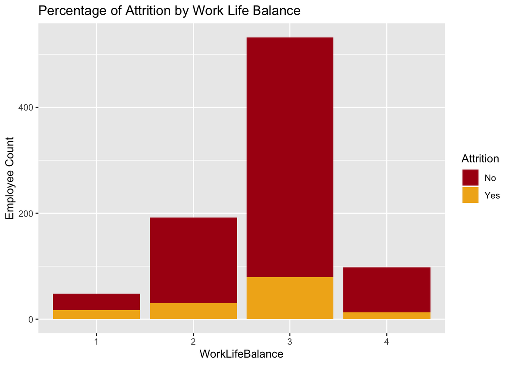

```r
CaseStudy2 %>%
  ggplot(aes(x= WorkLifeBalance, fill=Attrition)) +
  geom_bar(stat = "count") + scale_fill_manual(values = colors5) +
  ggtitle("Percentage of Attrition by Work Life Balance") + ylab("Employee Count")
```

```r
wlbtbl = table(CaseStudy2$WorkLifeBalance, CaseStudy2$Attrition)
wlbtbl
```

```
##
##      No Yes
##   1  31  17
##   2 162  30
##   3 452  80
##   4  85  13
```

```r
chisq.test(wlbtbl)
```

```
##
##  Pearson's Chi-squared test
##
## data:  wlbtbl
## X-squared = 14.325, df = 3, p-value = 0.002495
```

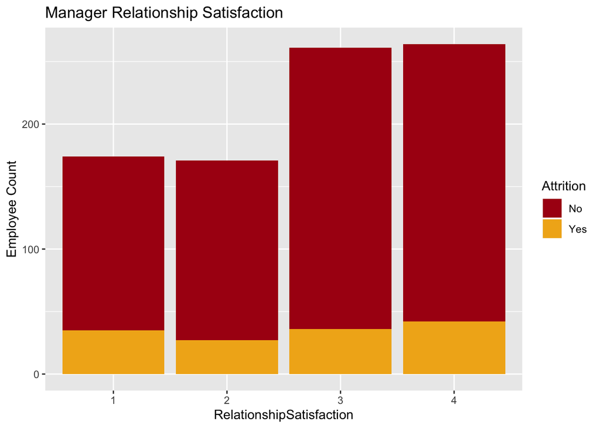

```r
CaseStudy2 %>%
  ggplot(aes(x= RelationshipSatisfaction, fill=Attrition)) +
  geom_bar(stat = "count") + scale_fill_manual(values = colors5) +
  ggtitle("Manager Relationship Satisfaction") + ylab("Employee Count")
```

```r
rstbl = table(CaseStudy2$RelationshipSatisfaction, CaseStudy2$Attrition)
rstbl
```

```
##
##      No Yes
##   1 139  35
##   2 144  27
##   3 225  36
##   4 222  42
```

```r
chisq.test(rstbl)
```

```
##
##  Pearson's Chi-squared test
##
## data:  rstbl
## X-squared = 3.1253, df = 3, p-value = 0.3727
```

##Boxplots of Numeric Data #Attrition=No group has higher median Age 2 DailyRate 5 MonthlyIncome 18 MonthlyRate 19 NumCompaniesWorked 20 TotalWorkingYears 26 Training 27 Years at Company 29 Years in current role 30 Years since last promotion 31

#Attrition=Yes has higher median DistanceFromHome 7 Hourlyrate 12

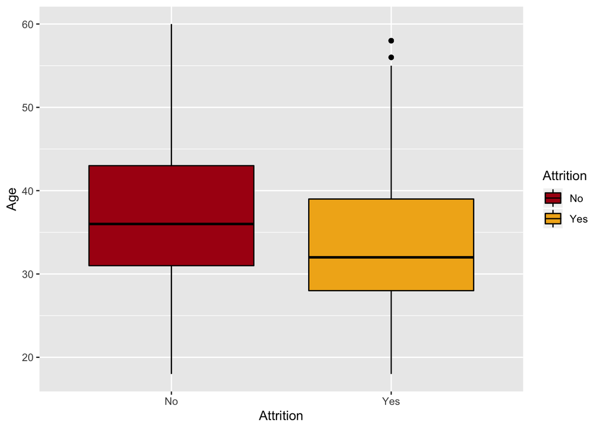

```r
#boxplot of attrition by age[2] - Different (Yes is lower)
CaseStudy2 %>% ggplot(aes(x = Attrition, y = Age, fill = Attrition)) + geom_boxplot(color = "black") + scale_fill_manual(values = colors2)
```

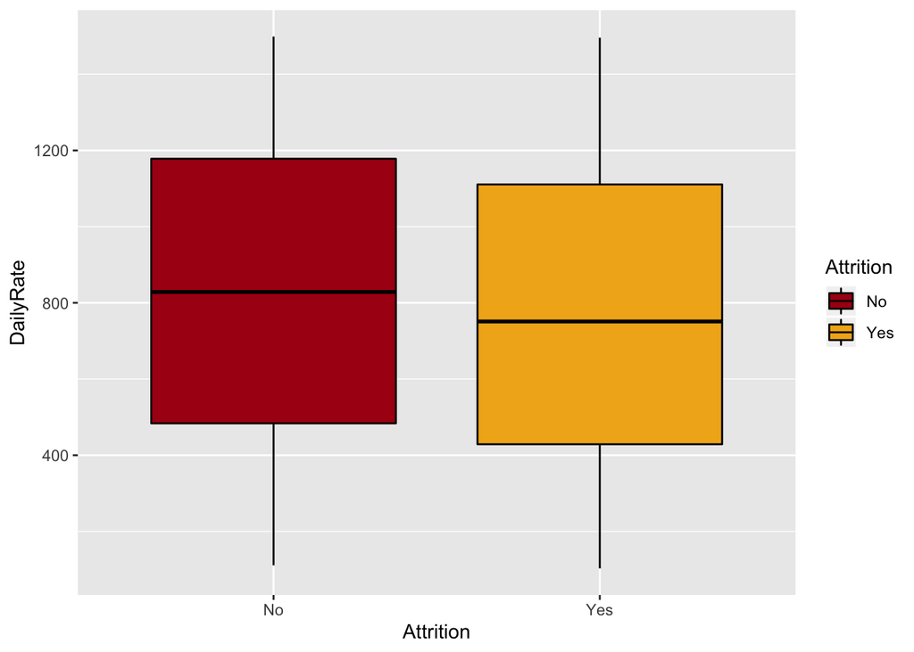

```r
#boxplot of attrition by daily rate[5] - Different (No is higher)
CaseStudy2 %>% ggplot(aes(x = Attrition, y = DailyRate, fill=Attrition)) + geom_boxplot(color = "black") + scale_fill_manual(values = colors2)
```

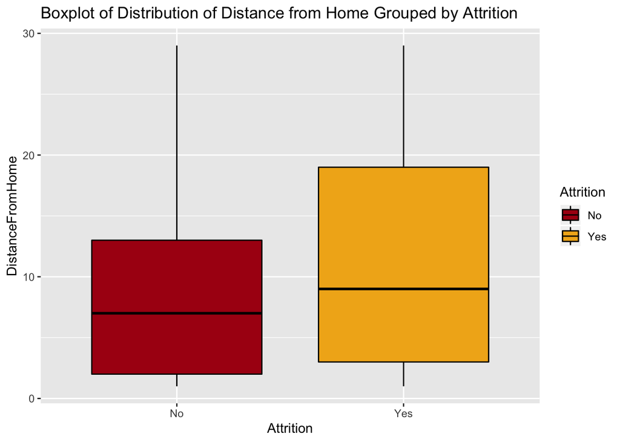

```r
#boxplot of attrition by distance from home[7] - Different (Yes is higher)
CaseStudy2 %>% ggplot(aes(x = Attrition, y = DistanceFromHome, fill=Attrition)) + geom_boxplot(color="black") + scale_fill_manual(values = colors2) + ggtitle("Boxplot of Distribution of Distance from Home Grouped by Attrition")
```

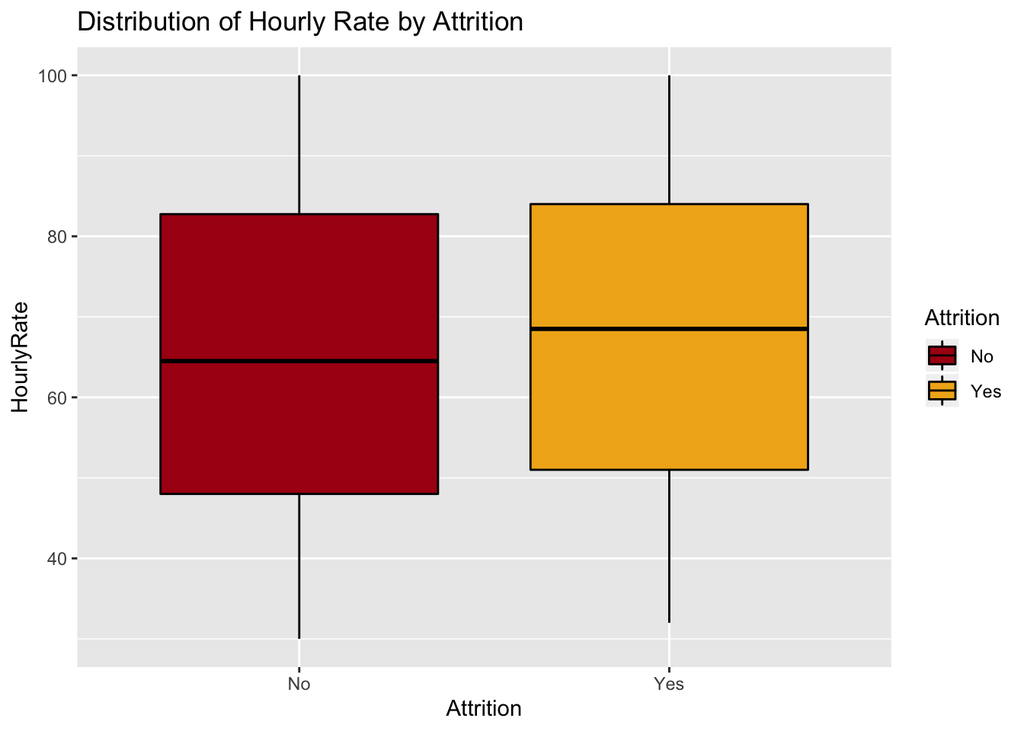

```r
#boxplot attrition by hourly rate[] - Different (Yes is higher (PT? Sales & Commission?))
CaseStudy2 %>% ggplot(aes(x = Attrition, y = HourlyRate, fill=Attrition)) + geom_boxplot(color="black") + scale_fill_manual(values = colors2)  + ggtitle("Distribution of Hourly Rate by Attrition")
```

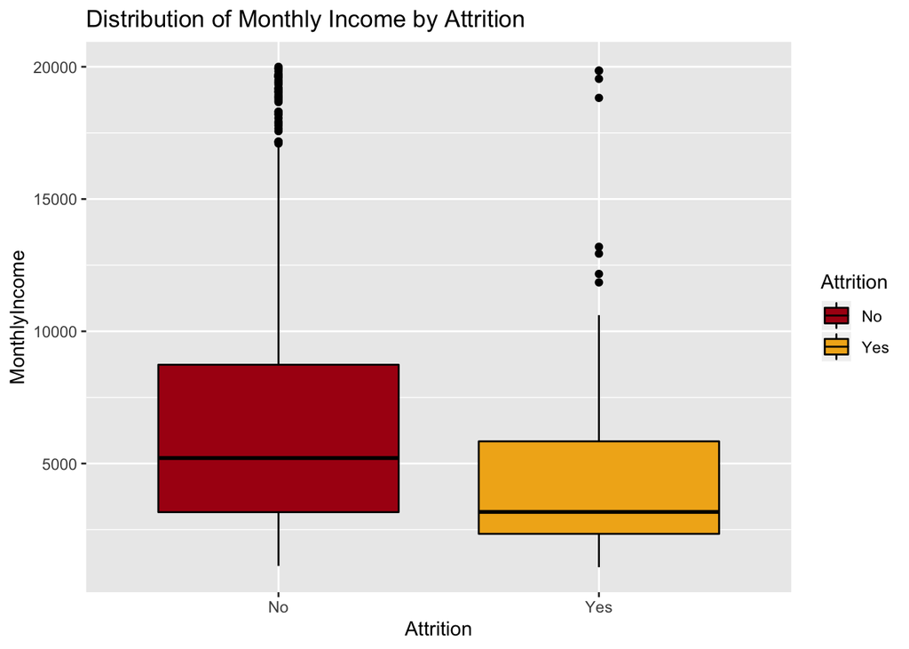

```r
#boxplot attrition by monthly income - Different (No is higher)
CaseStudy2 %>% ggplot(aes(x = Attrition, y = MonthlyIncome, fill=Attrition)) + geom_boxplot(color="black") + scale_fill_manual(values = colors2) + ggtitle("Distribution of Monthly Income by Attrition")
```

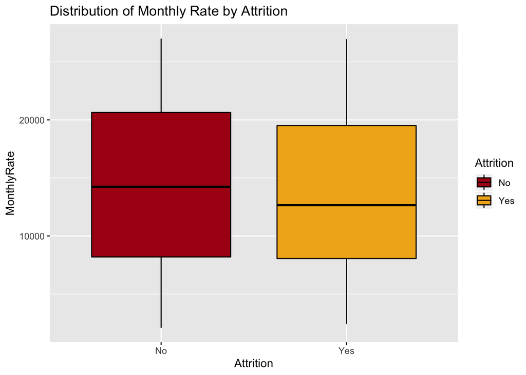

```r
#boxplot attrition by monthly rate - Different (No is higher)
CaseStudy2 %>% ggplot(aes(x = Attrition, y = MonthlyRate, fill=Attrition)) + geom_boxplot(color="black") + scale_fill_manual(values = colors2) + ggtitle("Distribution of Monthly Rate by Attrition")
```

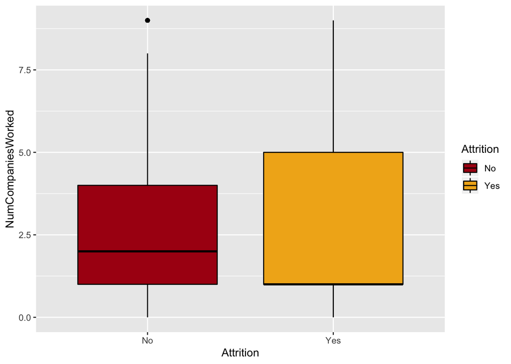

```r
#boxplot attrition by number of companies worked - Different (yes is lower)
CaseStudy2 %>% ggplot(aes(x = Attrition, y = NumCompaniesWorked, fill=Attrition)) + geom_boxplot(color="black") + scale_fill_manual(values = colors2)
```

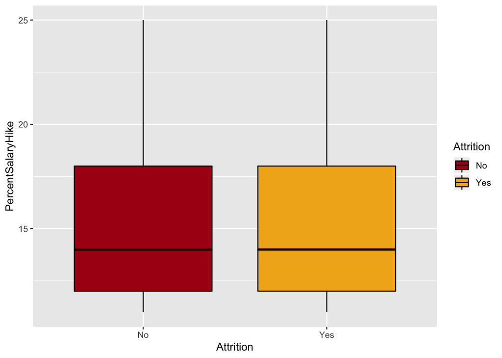

```r
#boxplot attrition by percent salary raise - Same
CaseStudy2 %>% ggplot(aes(x = Attrition, y = PercentSalaryHike, fill=Attrition)) + geom_boxplot(color="black") + scale_fill_manual(values = colors2)
```

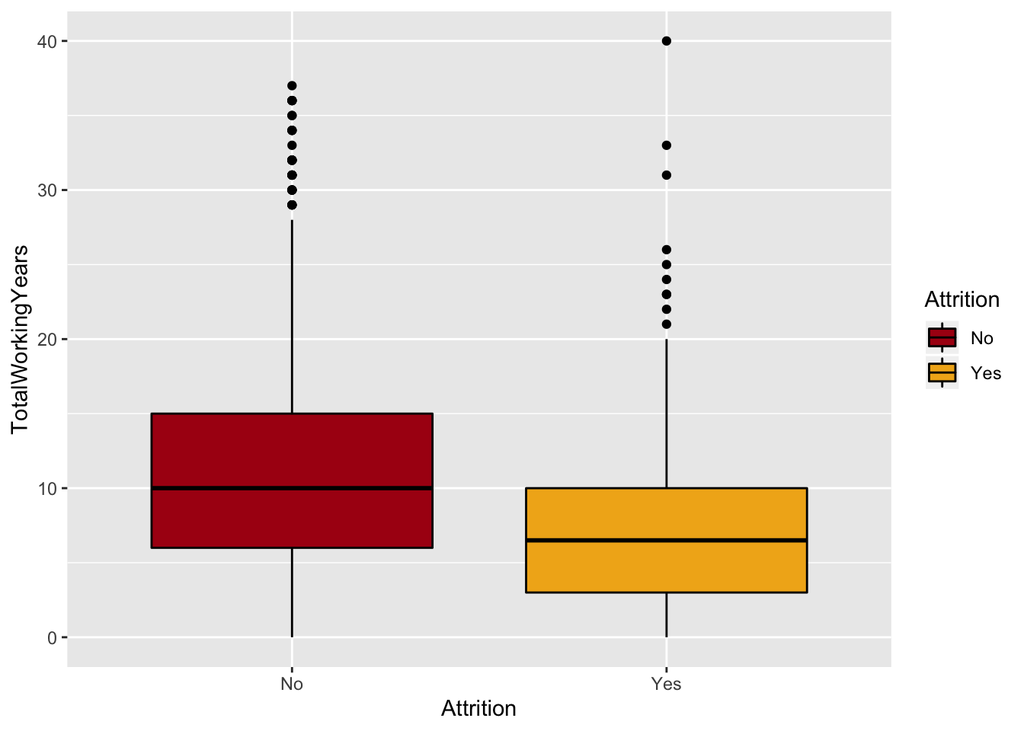

```r
#boxplot attrition by total working years - Different (Yes is lower)
CaseStudy2 %>% ggplot(aes(x = Attrition, y = TotalWorkingYears, fill=Attrition)) + geom_boxplot(color="black") + scale_fill_manual(values = colors2)
```

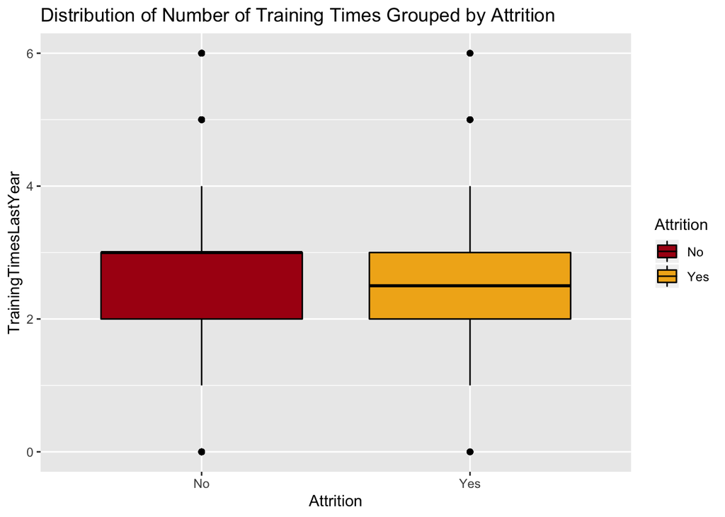

```r
#boxplot attrition by training last year - Different (Yes is lower)
CaseStudy2 %>% ggplot(aes(x = Attrition, y = TrainingTimesLastYear, fill=Attrition)) + geom_boxplot(color="black") + scale_fill_manual(values = colors2) + ggtitle("Distribution of Number of Training Times Grouped by Attrition")
```

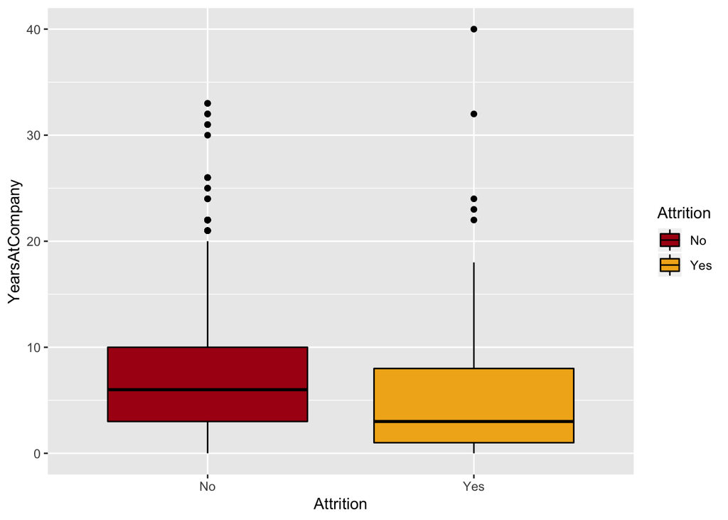

```r
#boxplot attrition by years at company - Different (Yes is lower)
CaseStudy2 %>% ggplot(aes(x = Attrition, y = YearsAtCompany, fill=Attrition)) + geom_boxplot(color="black") + scale_fill_manual(values = colors2)
```

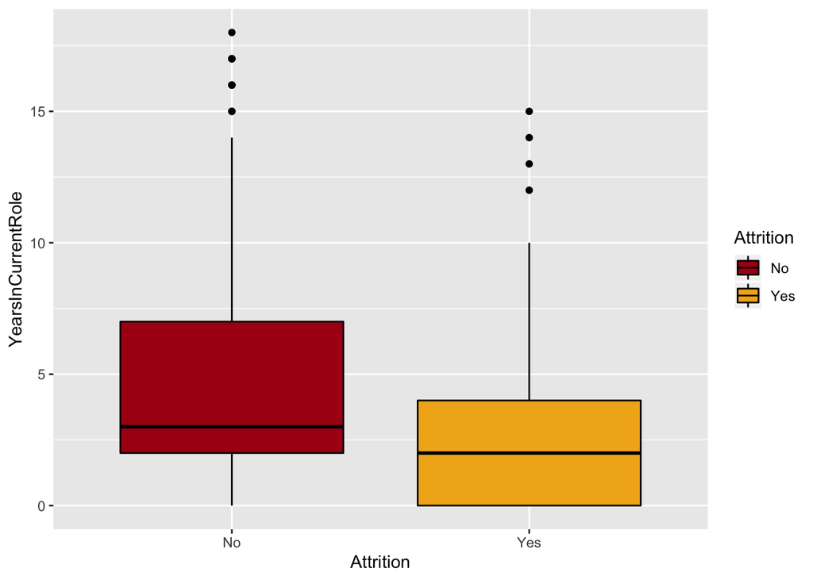

```r
#boxplot attrition by years in current role - Close (Yes is lower)
CaseStudy2 %>% ggplot(aes(x = Attrition, y = YearsInCurrentRole, fill=Attrition)) + geom_boxplot(color="black") + scale_fill_manual(values = colors2)
```